# Trabajo 2- Estadística 3

Cristina Mercedes Ortega Benavides

18/5/2021

# 1. Introducción

- Definición DANE del índice asignado (ecuación debidamente explicada) dando ejemplo interpretativo de sus valores
- Definición del dominio o clasificación industrial al que está relacionada la serie.
- Resultados alcanzados en el trabajo 1
- Cuáles modelos globales y locales que fueron propuestos (debe dar las ecuaciones teóricas)
- Cuál es el mejor modelo global, qué logró explicar este modelo en relación a los patrones que fueron observados sobre la serie
- Resultó mejor el ajuste y pronóstico global vs. lo local (cuál fue el mejor local entre Holt-Winters y combinación del filtro de la descomposición con loess) y por qué.

# 2. Análisis descriptivo de la serie, modelo global asignado y sus resultados:

1. Presente y analice brevemente la gráfica de la serie (y su logaritmo natural si la serie es multiplicativa) indicando los patrones observables de tendencia, estacionalidad, varianza, ciclos. Grafique y analice además la ACF de la serie (para el caso multiplicativo sólo presente y analice la ACF del logaritmo natural) y concluya en términos de estacionariedad o no y por qué, contrastando con lo que a partir de la gráfica de la serie se concluye al respecto.

```r
Datos20=read.table("anex-EMMET-dic2019-Fabricacion de otros productos quimicos (1).csv",header=T,sep=";",skip=14,dec=",",colClasses=c(rep("NULL",4),"numeric",rep("NULL",6)))

Datos20=ts(Datos20,freq=12,start=c(2001,1))
```

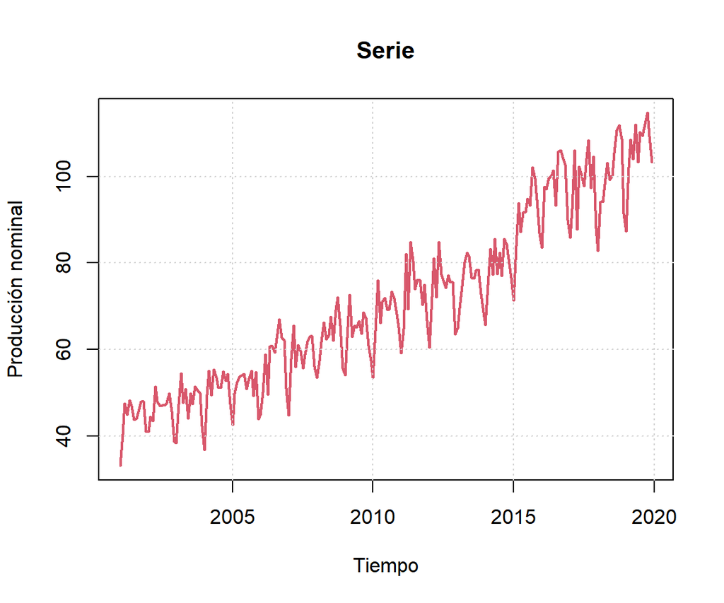

```r
plot(Datos20, lwd=2, xlab="Tiempo", ylab = "Producción nominal", col = "#d8576b")
grid()
title(main = "Serie")
```

```r
require(forecast)
```

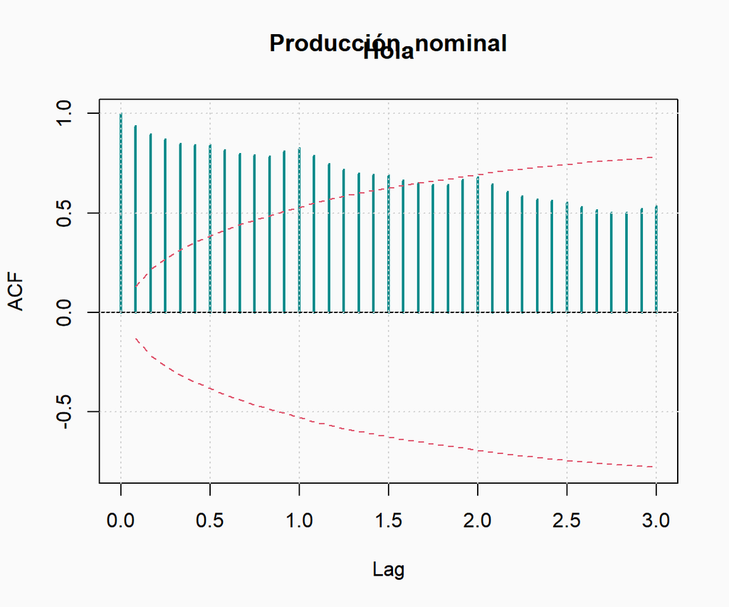

```r
par(bg='gray98')
acf(Datos20,lag.max=36,ci.type="ma",col="cyan4", ci.col=2, lwd=2, ci.lwd=2)
title(main = 'Hola')
grid()
```

2. Para el modelo de regresión global señalado en la Tabla 1
- la ecuación teórica con sus supuestos

$$\text{Modelo cuadrático estacional con indicadoras, mes de referencia diciembre}\\
Y_t=\beta_0+\beta_1t+\beta_2t^2+\sum_{i=1}^{11}\delta_iI_{i,t}+E_t, ~~~ \{E_t\}_{t\in Z^+} \text{un RB} \sim N(0, \sigma^2)$$

- con la estrategia de validación cruzada usando la misma longitud n = 216 de ajuste del trabajo anterior ajuste nuevamente este modelo y reporte los resultados de ajuste

```r
m <- 12 # numero de periodos a pronosticar dentro de la muestra
n <-length(Datos20)-m # tamaño de la muestra para el ajuste
t <- 1:n #Indice de tiempo en los periodos de ajuste

# Datos para el ajuste:

yt <- ts(Datos20[t], frequency = 12, start=c(2001, 1))

# Creación de las variables indicadoras para los datos de muestra

mes <- seasonaldummy(yt) #Matriz con las 11 primeras variables Indicadoras mes

#Separando una a una las 11 variables indicadoras

I1 <- mes[,1]
I2 <- mes[,2]
I3 <- mes[,3]
I4 <- mes[,4]
I5 <- mes[,5]
I6 <- mes[,6]
I7 <- mes[,7]
I8 <- mes[,8]
I9 <- mes[,9]
I10 <- mes[,10]
I11 <- mes[,11]

# Creación de las variables indicadoras para los datos de validación cruzada

tnuevo <- (n+1):length(Datos20)
ytnuevo <- ts(Datos20[tnuevo], frequency = 12, start = c(2019, 1))


mesnuevo <- seasonaldummy(yt, h=12)
#Separando una a una las 11 indicadoras para los tiempos de pron?stico
I1n=mesnuevo[,1]
I2n=mesnuevo[,2]
I3n=mesnuevo[,3]
I4n=mesnuevo[,4]
I5n=mesnuevo[,5]
I6n=mesnuevo[,6]
I7n=mesnuevo[,7]
I8n=mesnuevo[,8]
I9n=mesnuevo[,9]
I10n=mesnuevo[,10]
I11n=mesnuevo[,11]

## Ajuste del Modelo cuadrático estacional con indicadoras

mod1 <- lm(yt~t+I(t^2)+I1+I2+I3+I4+I5+I6+I7+I8+I9+I10+I11)
```

- tabla de parámetros estimados

$$\begin{array}{| c | c | c | c| c |}
\hline
Parametro&Estimación&Error~Estándar&T_0&P(|T_{202}|>|T_0|)\\
\hline
\beta_0&35.8242551&1.2250562&29.242949&0.0000000\\
\beta_1&0.1319807&0.0174478&7.564309&0.0000000\\
\beta_2&0.0007051&0.0000779&9.055350&0.0000000\\
\delta_1&-3.1817818&1.3273503&-2.397093&0.0174368\\
\delta_2&5.3069465&1.3272009&3.998601&0.0000893\\
\delta_3&12.0220423&1.3270660&9.059114&0.0000000\\
\delta_4&7.2690612&1.3269454&5.478041&0.0000001\\
\delta_5&12.1146698&1.3268389&9.130475&0.0000000\\
\delta_6&9.8255350&1.3267465&7.405736&0.0000000\\
\delta_7&8.4294343&1.3266681&6.353838&0.0000000\\
\delta_8&9.0930346&1.3266037&6.854372&0.0000000\\
\delta_9&12.5163357&1.3265533&9.435230&0.0000000\\
\delta_{10}&10.5493377&1.3265171&7.952659&0.0000000\\
\delta_{11}&8.9475962&1.3264952&6.745291&0.0000000\\
\hline
\end{array}$$

```r
summary(mod1)
```

```
##
## Call:
## lm(formula = yt ~ t + I(t^2) + I1 + I2 + I3 + I4 + I5 + I6 +
##     I7 + I8 + I9 + I10 + I11)
##
## Residuals:
##      Min       1Q   Median       3Q      Max
## -11.2796  -2.4057  -0.1672   2.2769  11.0489
##
## Coefficients:
##               Estimate Std. Error t value Pr(>|t|)
## (Intercept)  3.582e+01  1.225e+00  29.243  < 2e-16 ***
## t            1.320e-01  1.745e-02   7.564 1.35e-12 ***
## I(t^2)       7.051e-04  7.787e-05   9.055  < 2e-16 ***
## I1          -3.182e+00  1.327e+00  -2.397   0.0174 *
## I2           5.307e+00  1.327e+00   3.999 8.93e-05 ***
## I3           1.202e+01  1.327e+00   9.059  < 2e-16 ***
## I4           7.269e+00  1.327e+00   5.478 1.27e-07 ***
## I5           1.211e+01  1.327e+00   9.130  < 2e-16 ***
## I6           9.826e+00  1.327e+00   7.406 3.47e-12 ***
## I7           8.429e+00  1.327e+00   6.354 1.37e-09 ***
## I8           9.093e+00  1.327e+00   6.854 8.50e-11 ***
## I9           1.252e+01  1.327e+00   9.435  < 2e-16 ***
## I10          1.055e+01  1.327e+00   7.953 1.28e-13 ***
## I11          8.948e+00  1.326e+00   6.745 1.57e-10 ***
## ---
## Signif. codes:  0 '***' 0.001 '**' 0.01 '*' 0.05 '.' 0.1 ' ' 1
##
## Residual standard error: 3.979 on 202 degrees of freedom
## Multiple R-squared:  0.9589, Adjusted R-squared:  0.9562
## F-statistic: 362.3 on 13 and 202 DF,  p-value: < 2.2e-16
```

```r
require(kableExtra)
require(broom)
# tidy(summary(mod1)) %>%
#   kbl() %>%
#   kable_classic()
```

- medidas de ajuste

```r
# Calculo del AIC y BIC

#Creando funci?n usuario crit.inf.resid() para calcular C^*_n(p)
crit.inf.resid <- function(residuales,n.par,AIC="TRUE"){
if(AIC=="TRUE"){
#Calcula AIC
CI=log(mean(residuales^2))+2*n.par/length(residuales)
}
if(AIC=="FALSE"){
#Calcula BIC
CI=log(mean(residuales^2))+n.par*log(length(residuales))/length(residuales)
}
CI
}
```

modelo 1

```r
resmod1.orig <- residuals(mod1) #seudo-residuos en la escala original. Usados solo para calcular AIC y BIC

npar1 <- length(coef(mod1)[coef(mod1)!=0]) #numero parametros modelo 1

AIC1 <- exp(crit.inf.resid(resmod1.orig,n.par=npar1))
BIC1 <- exp(crit.inf.resid(resmod1.orig ,n.par=npar1, AIC="FALSE"))
```

$$\begin{array}{| c | c | c |}
\hline
p&AIC&BIC\\
\hline
14&16.85948&20.98234\\
\hline
\end{array}$$

- gráfico del ajuste

# Valores ajustados de los modelos

```r
mod1_ajust <- ts(fitted(mod1), start  = c(2001,1), frequency = 12)
```

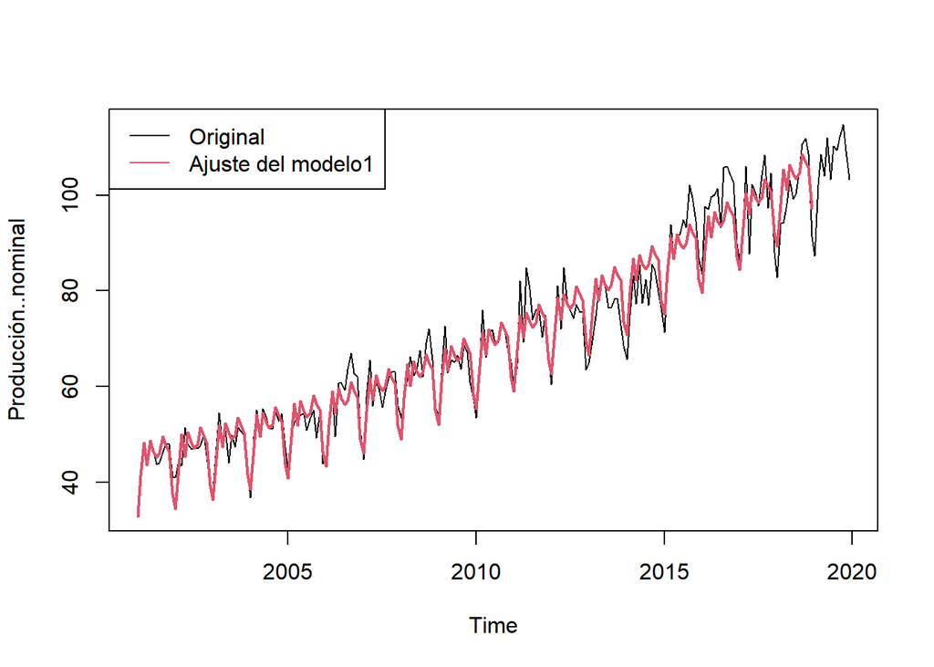

```r
plot(Datos20)
lines(mod1_ajust, col=2, lwd=2)
legend("topleft", legend = c("Original", "Ajuste del modelo1"), lty=1, col=c(1,2))
```

- pronósticos
- Ecuación de pronóstico
- la tabla de pronósticos

$$\begin{array}{| c | c | c | c| c |}
\hline
Periodo&L&Pronósticos&Lim.Inf&Lim.Sup\\
\hline
Ene~2019&1&94.4852&86.27520&102.6952\\
Feb~2019&2&103.4126&95.19741&111.6279\\
Mar~2019&3&110.5678&102.34725&118.7884\\
Abr~2019&4&106.2564&98.03028&114.4825\\
May~2019&5&111.5449&103.31316&119.7767\\
Jun~2019&6&109.7001&101.46257&117.9377\\
Jul~2019&7&108.7498&100.50627&116.9933\\
Ago~2019&8&109.8606&101.61094&118.1102\\
Sep~2019&9&113.7324&105.47658&121.9883\\
Oct~2019&10&112.2154&103.95319&120.4777\\
Nov~2019&11&111.0651&102.79632&119.3338\\
Dic~2019&12&102.5703&94.29486&110.8457\\
\hline
\end{array}$$

- medidas de cobertura amplitud media de los I.P y medidas MAE, MAPE y RMSE

$$\begin{array}{| c | c | c | c| c |}
\hline
RMSE & MAE & MAPE & Amplitud & Cobertura\\
\hline
3.153708&2.366654&2.338060&16.48278&100\\
\hline
\end{array}$$

- Conclusión breve sobre la calidad del ajuste y de los pronósticos con este modelo

# 3. Evaluación de supuesto de ruido blanco e identificación de procesos estocásticos sobre los errores estructurales del modelo global

1. Validación de supuestos: Guarde los residuos estructurales $\hat{E}_t$ en la escala en que ajustó la serie. Analice inicialmente las gráficas de estos residuales en términos de los supuestos sobre los errores Et de media constante en cero, varianza constante y determine si hay ciclos evidentes no explicados o rachas en signos ±, qué concluye frente a la existencia de estos patrones.

```r
residuales <- residuals(mod1)
```

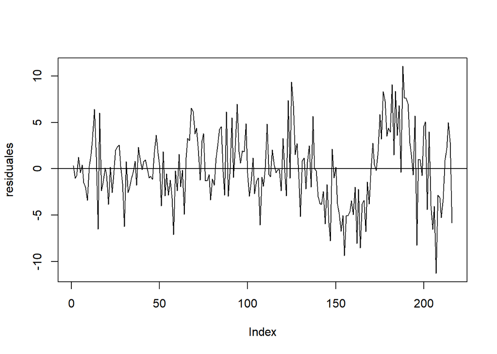

```r
plot(residuales, type = "l")
abline(h = 0)
```

Realice las Pruebas de incorrelación con:

- Ljung-Box

```r
#DEFINIENDO FUNCION USUARIO PARA TESTES BOX-PIERCE Y LJUNG-BOX
BP.LB.test=function(serie,maxlag,type="Box"){
aux=floor(maxlag/6); X.squared=c(rep(NA,aux))
df=c(rep(NA,aux)); p.value=c(rep(NA,aux))
for(i in 1:aux){
test=Box.test(serie,lag=(6*i),type=type)
X.squared[i]=test[[1]]; df[i]=test[[2]]
p.value[i]=test[[3]]
}
lag=6*c(1:aux)
teste=as.data.frame(cbind(X.squared,df,p.value))
rownames(teste)=lag; teste
}

BP.LB.test(residuals(mod1),maxlag=36,type="Ljung")
```

```
##    X.squared df p.value
## 6   161.9070  6       0
## 12  196.2375 12       0
## 18  216.3132 18       0
## 24  259.1398 24       0
## 30  315.9719 30       0
## 36  385.4793 36       0
```

- Durbin-Watson

```r
require(car)
#DEFINIENDO FUNCION USUARIO PARA TEST DURBIN-WATSON
pruebaDW1=function(modelo){
dwneg=durbinWatsonTest(modelo,max.lag=1,method="normal",alternative="negative")
dwpos=durbinWatsonTest(modelo,max.lag=1,method="normal",alternative="positive")

res=data.frame(1,dwneg$r,dwneg$dw,dwpos$p,dwneg$p)
names(res)=c("lag","rho estimado","Estadístico D-W",
"VP rho>0","VP rho<0")
res
}

pruebaDW1(mod1)
```

```
##   lag rho estimado Estadístico D-W VP rho>0 VP rho<0
## 1   1    0.4099877        1.169368        0        1
```

- gráficas de la ACF y PACF con bandas de Bartlett.

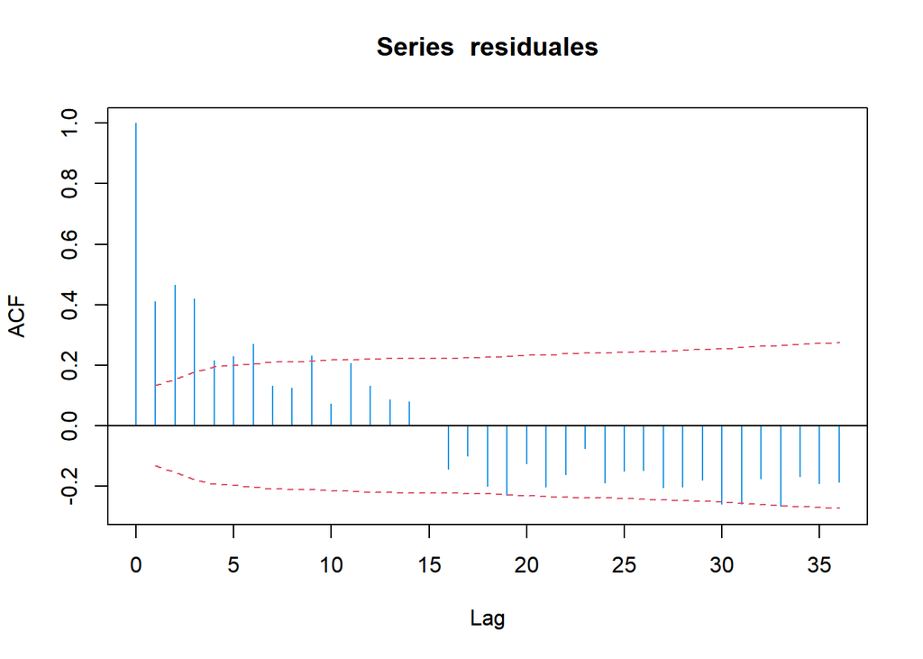

```r
acf(residuales,lag.max=36,ci.type="ma",col=4,ci.col=2)
```

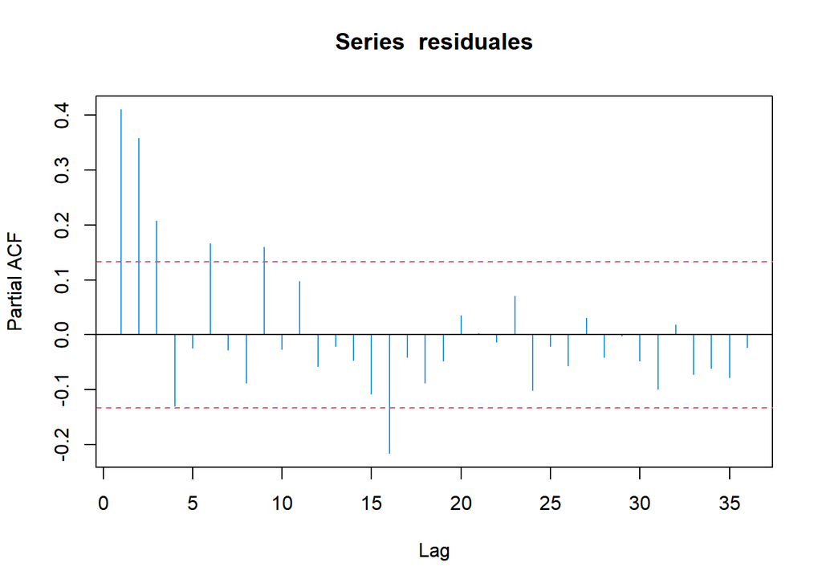

```r
pacf(residuales,lag.max=36,col=4,ci.col=2)
```

Concluya sobre si los errores estructurales Et son ruido blanco o no y en este último caso, evalúe si por lo menos son estacionarios con media cero.